# SOK-1005 Data science project

Data science project spring 2023.

Author

Affiliation

Candidate number 3  
Candidate number 11

UiT The Arctic University of Norway  
Faculty of Biosciences, Fisheries and Economics.

Published

June 1, 2023

The files has been split into Task1 and one for Task 2, 3 and 4. This has been done after we recieved an email telling us we needed this to deliver. The Full project is the unedited version.

If you prefer to use the GitHub hosted files, then use these links

[Task 1](https://danielfabiog.github.io/SOK-1005/Prosjektoppgave/3_11_Task1_SOK1005_Project_V23.html)  
[Tasks 2, 3 and 4](https://danielfabiog.github.io/SOK-1005/Prosjektoppgave/3_11_Task2_3_4_SOK1005_Project_V23.html)  
[Full project (Recommended)](https://danielfabiog.github.io/SOK-1005/Prosjektoppgave/index.html)

If you have downloaded the files, then use these links

Task 1  
Tasks 2, 3 and 4  
Full project (Recommended)

## Task 1

We have now been hired as analysts at Insight Analytics (IA), and the company that “owns” our data wants to develop a system that can report sales for all their outlets in the group. To demonstrate what we can deliver, they have announced a tender competition, and our task is to participate in the competition by solving a series of tasks.

The first task we are to undertake is to write code in R that combines the four datasets they have given us into one large dataset.

```r
rm(list=ls()) #cleaning our environment
# Load required libraries
library(tidyverse)
library(haven)
library(curl)
library(utils)
library(janitor)
library(glue)
library(leaflet)
library(knitr)
library(plotly)


# Code to be used to see what type of category we get to work with
category <- c("Analgesics","Bath Soap","Beer","Bottled Juices","Cereals",
              "Cheeses","Cigarettes","Cookies","Crackers","Canned Soup",
              "Dish Detergent","Front-end-candies","Frozen Dinners","Frozen Entrees",
              "Frozen Juices","Fabric Softeners","Grooming Products","Laundry Detergents",
              "Oatmeal","Paper Towels","Soft Drinks","Shampoos","Snack Crackers",
              "Soaps","Toothbrushes","Canned Tuna","Toothpastes","Bathroom Tissues")

letter2number <- function(x) {utf8ToInt(x) - utf8ToInt("A") + 1L}
seed_number <- sum(letter2number("Daniel")) + sum(letter2number("Daniel"))
set.seed(seed_number)
cat(glue("Our seed number is {seed_number} so our category is {sample(category, 1)}")) #Making a print function to display nicer in html
```

```
Our seed number is 410 so our category is Shampoos
```

```r
# We free up ram by removing old dataframes we dont need to keep loaded.
rm(category, letter2number, seed_number)
```

We start by loading the packages we will use to do the tasks. Then we run the code that ensures we know which product category we are given with our “seed” which is Shampoo.

```r
# Storing the urls in a list
urls <- c(
  "https://www.chicagobooth.edu/boothsitecore/docs/dff/store-demos-customer-count/ccount_stata.zip",
  "https://www.chicagobooth.edu/boothsitecore/docs/dff/store-demos-customer-count/demo_stata.zip",
  "https://www.chicagobooth.edu/-/media/enterprise/centers/kilts/datasets/dominicks-dataset/movement_csv-files/wsha.zip"
)

# Storing the zip files in a list
zip_files <- c("ccount_stata.zip", "demo_stata.zip", "wsha.zip")
# Looping through the URLs and download and impotr the files
for (i in seq_along(urls)) {
  #Downloading the zip file
  curl_download(urls[i], zip_files[i])

  # Unzipping file in loop
  unzip(zip_files[i], exdir = "data")

  # Finding the .dta and .csv files and calling it stata_file
  stata_file <- c(
  list.files("data", pattern = ".*\\.dta", full.names = TRUE),
  list.files("data", pattern = ".*\\.csv", full.names = TRUE)
)

  # Loop to create dfs
  for (stata_file in stata_file) {
    if (grepl("ccount.dta", stata_file)) {
      ccount_stata <- read_stata(stata_file)
    } else if (grepl("demo.dta", stata_file)) {
      demo_stata <- read_stata(stata_file)
    }
    else if (grepl("wsha.csv", stata_file)) {
      wsha <- read_csv(stata_file)
    }
  }
}
#Reading csv for df
upcsha <- read_csv("https://www.chicagobooth.edu/-/media/enterprise/centers/kilts/datasets/dominicks-dataset/upc_csv-files/upcsha.csv")
#Finally we can delete and unlink the files now thats imported into R.
file.remove(zip_files)
```

```
[1] TRUE TRUE TRUE
```

```r
unlink("data", recursive = TRUE)

#We free up ram by removing old dataframes we dont need to keep loaded.
rm(urls, zip_files, stata_file, i)
```

This code downloads and imports data files from different websites and unpacks them into a folder. It then identifies the .dta and .csv files, and creates data frames from these files. Finally, it downloads a CSV file from another website and creates a final data frame from this file. All this is done using loops, so it does not have to be done manually each time. In the end, the code deletes the temporary files that were downloaded and unpacked.

```r
#Defining the start date of week 1
week_1_start <- as.Date("1989-09-14") #Please see appendix for usage of AI

#CLEANING DATA BLOCK
ccount_stata <- remove_empty(ccount_stata, which = "cols")  #Removing all columns with only NA
ccount_stata2 <- ccount_stata %>%
  mutate(date = ymd(date)) %>% #Forcing date onto date column making NAs where there are invalid dates
  filter(!is.na(date)) %>% #Dropping NA rows
  filter(date >= as.Date("1992-02-20") & date <= as.Date("1999-12-31")) %>%  #We only have data from 1992 so we filter for that
  mutate(week = as.integer((date - week_1_start) / 7) + 1) %>%#Creating week column. Please see appendix for usage of AI
  select(week, store, custcoun, haba) %>% #Grabbing only the data we want
  group_by(week, store) %>% #grouping by to aggregate to weekly
  summarise_all(sum) #aggregating to weekly so we can merge the dataframes
```

```r
#Copied the table from the PDF and pasted it into chatGPT to have it write out all the variables for me, i then put it into this list. I did the same with Description.

variable_names <- c("age9", "age60", "ethnic", "educ", "nocar", "income", "incsigma", "hsizeavg", "hsize1", "hsize2", "hsize34", "hsize567", "hh3plus", "hh4plus", "hhsingle", "hhlarge", "workwom", "sinhouse", "density", "hval150", "hval200", "hvalmean", "single", "retired", "unemp", "wrkch5", "wrkch17", "nwrkch5", "nwrkch17", "wrkch", "nwrkch", "wrkwch", "wrkwnch", "telephn", "mortgage", "nwhite", "poverty", "shopcons", "shophurr", "shopavid", "shopstr", "shopunft", "shopbird", "shopindx", "shpindx") #Please see appendix for AI usage


navn_for_demo_stata <- tibble(
  variable_name = c("age9", "age60", "ethnic", "educ", "nocar", "income", "incsigma", "hsizeavg", "hsize1", "hsize2", "hsize34", "hsize567", "hh3plus", "hh4plus", "hhsingle", "hhlarge", "workwom", "sinhouse", "density", "hval150", "hval200", "hvalmean", "single", "retired", "unemp", "wrkch5", "wrkch17", "nwrkch5", "nwrkch17", "wrkch", "nwrkch", "wrkwch", "wrkwnch", "telephn", "mortgage", "nwhite", "poverty", "shopcons", "shophurr", "shopavid", "shopstr", "shopunft", "shopbird", "shopindx", "shpindx"),
  description = c("% Population under age 9", "% Population over age 60", "% Blacks & Hispanics", "% College Graduates", "% With No Vehicles", "Log of Median Income", "Std dev of Income Distribution (Approximated)", "Average Household Size", "% of households with 1 person", "% of households with 2 persons", "% of households with 3 or 4 persons", "% of households with 5 or more persons", "% of households with 3 or more persons", "% of households with 4 or more persons", "% of households with 1 person", "% of households with 5 or more persons", "% Working Women with full-time jobs", "% Detached Houses", "Trading Area in Sq Miles per Capita", "% of Households with Value over $150,000", "% of Households with Value over $200,000", "Mean Household Value (Approximated)", "% of Singles", "% of Retired", "% of Unemployed", "% of working women with children under 5", "% of working women with children 6 - 17", "% of non-working women with children under 5", "% of non-working women with children 6 - 17", "% of working women with children", "% of non-working women with children", "% of working women with children under 5", "% of working women with no children", "% of households with telephones", "% of households with mortgages", "% of population that is non-white", "% of population with income under $15,000", "% of Constrained Shoppers", "% of Hurried Shoppers", "% of Avid Shoppers", "% of Shopping Stranges", "% of Unfettered Shoppers", "% of Shopper Birds", "Ability to Shop (Car and Single Family House)", "Ability to Shop (Car and Single Family House)") #please see appendix for AI usage
)


# Creating a variable_list to filter out only the variables we want
variable_list <- c("hvalmean", "incsigma", "income", "nocar", "sinhouse", "shopindx", "shpindx", "hh3plus", "hh4plus", "hhsingle", "hhlarge", "density", "wrkch5", "nwrkch5", "wrkwch", "telephn")

#We then selrct what to keep outside of variable_list and what to keep inside of variable_list
demo_stata <- demo_stata %>%
  select(name, city, zip, lat, long, store, variable_names[variable_names %in% names(demo_stata)]) %>%
  select(-all_of(variable_list))

#We then remove to free up ram
rm(variable_list, variable_names)
```

Then, the names of the variables and their descriptions are stored in two separate lists. After that, a new table is created with columns for variable names and descriptions.

Next, a list of variable names is created to filter out only the variables that are desired. Then, the data table is filtered by retaining columns that are included in the variable name list but excluding columns that are included in another list called “variable_list”.

```r
# Set the scipen option to 999 to avoid scientific notation when printing large numbers
options(scipen = 999)

#Dropping NA
demo_stata <- demo_stata %>%
  drop_na()

# We want to make figures, but the dataframe does not have data to summarize some of the percentages to 100 so we have to calculate this in the mutate functions to find the missing percentage, we store those in the variables agebetween, % white etc.
demo_stata <- demo_stata %>%
  mutate("% of population that is between the age of 9 and 60" = 1- age9-age60) %>%
  mutate("% of population that is white" = 1-nwhite) %>%
  mutate("% of population that is neither black & hispanics or white" = nwhite-ethnic) %>%
  mutate("% of people that arent college graduates" = 1-educ) %>%
  mutate("% of women that arent working" = 1-workwom) %>%
  mutate("% of households without mortages" = 1-mortgage) %>%
  mutate("% of population with income over $15,000" = 1-poverty)

# Pivot the demo_stata data frame to a longer format
df_long <- demo_stata %>%
  pivot_longer(cols = -c(name, city, zip, lat, long, store),# Specifing the columns not to pivot
               names_to = "variable_name",# Set the new column name for the values
               values_to = "value")# Set the new column name for the values

# Fixing so that the variable names become the description instead of the shorcuts, it looks much better and gives more information
df_long <- df_long %>%
  left_join(navn_for_demo_stata, by = "variable_name") %>%
  mutate(variable_name = ifelse(is.na(description), variable_name, description)) %>%
  select(-description)

# We then remove the dataframe we dont need anymore
rm(navn_for_demo_stata)
```

Here, the scipen option is set to 999 to avoid scientific notation when large numbers are printed out, and the drop_na function is used to remove NAN values from the dataset. We use the mutate function to calculate the final percentage values to sum the percentages to 100.

Finally, in this block of code, we make the dataset longer, and arrange for the variable names to be replaced with the description of what they do so we get more information. In the end, we remove the description and a dataset we don’t need further.

```r
# Merge the movement file with the UPC file
df <- wsha %>%
  select(-SALE) %>% #Dropping SALE that indicates if it was a sale
  inner_join(upcsha, by = "UPC") %>% #inner join for only taking the UPC
  clean_names() %>% #Using janitor to clean the names
  mutate(date = week_1_start + (week - 1) * 7) %>%
  select(date, everything()) %>% #and we sort it to have date first
  filter(move > 0, ok == 1) %>% #Using only aggregated sales and only valid data
  mutate(sales = price * move / qty) %>%   #calculating total dollar sales
  select(-price_hex, -profit_hex, -ok) #dropping hex values for price and profit
df <- df %>%
  inner_join(ccount_stata2, by = c("week", "store"))

final_df <- df %>%
  filter(date >= "1993-12-30" & date <= "1995-01-03") %>%  #Filtering for only data in 1994 since we lack data for 1990-1993
  select(-com_code, -upc, nitem)


#We free up ram by removing old dataframes we dont need to keep loaded.
rm(demo_stata, df, ccount_stata, ccount_stata2, upcsha, wsha, week_1_start)
```

The code begins by performing a merge of two datasets using UPC as the key. Then the column indicating whether it was a sales transaction, “SALE”, is removed and the column names are tidied up using the janitor package. Afterwards, a new column called “date” is created using “week_1_start” and the number of weeks. Then, the dataset is filtered to only include aggregate sales and valid data, and a new dataset is created by filtering data from the year 1994. Finally, memory is freed by removing the datasets that are no longer necessary.

```r
#creating a list of brands to use in the loop
brands <- c("vo5", "spirit", "bold_hold", "head_and_shoulders", "ivory")

#Here we had the help of ChatGPT to create the REGEX code
#Creating a list of patterns to look for to get every type of different name of the shampoos
patterns <- c("V\\s*[-|]?\\s*O?\\s*5", "(teen|TN)\\s*sp[i|]r[i|]t", "BOLD\\s*HOLD", "(H&S|HEAD\\s*&\\s*SHOULDERS|HEAD\\s*&\\s*SHLDRS?|HD\\s*&\\s*SHLDRS?|H\\s*&\\s*S)", "IVORY") #please see appendix for AI usage
# Storing this in results
results <- list()

# Loop for taking out the shampoo brands we want in the final dataframe
for (i in seq_along(brands)) {
  data <- final_df %>%
    # we filter for the patterns in the loop
    filter(str_detect(descrip, regex(patterns[i], ignore_case = TRUE))) %>%
    # group the filtered observations
    group_by(date, store, week) %>%
    # Summarize it only if it is numeric
    summarise_if(is.numeric, sum, na.rm = TRUE) %>%
    # mutate it to store these in different dataframes for the type of brand
    mutate(brand = brands[i])
  # then store this in the empty list results
  results[[brands[i]]] <- data
}

# Removing to free up ram
rm(brands,i,patterns, final_df)
```

The code creates a list of different shampoo brands, and a list of different patterns to find the names of these brands. Then, the code creates an empty list called **`results`**. A loop goes through each brand and uses the patterns to filter and group data in **`final_df`** for each brand, then adds the results to the **`results`** list.

```r
df <- results[["vo5"]] %>%
  bind_rows(results[["spirit"]]) %>% #Combining the rows from the other dataset into df to make one final dataframe.
  bind_rows(results[["bold_hold"]]) %>%
  bind_rows(results[["head_and_shoulders"]]) %>%
  bind_rows(results[["ivory"]])

# Demo_stata finally joins the complete and finished df

df <- df %>%
  left_join(df_long, by="store") %>%
  rename(dflong_value = value) %>%
  select(-nitem, -case)


df <- df %>%
   pivot_wider(names_from = "variable_name", values_from = dflong_value) %>%
   select(-47) #Removing NA col


# Remove the last dataframe
rm(results,data,df_long)

write.csv(df, "sok-1005_data.csv", row.names = FALSE) #We write the dataframe to a csv file. rownames=false means that the rownames will not be written to the file.
```

The code first takes the different data frames from the various brands, and binds them together into a final data frame (df). Then, the code performs a left join with another data frame (df_long) and renames the ‘value’ column in df_long to ‘dflong_value’ to avoid confusion. We widen the dataframe to reduce the amount of the space required for the file. The code writes the ‘df’ data frame to a csv file called “sok-1005_data.csv” without row names. Finally, the last data frames are removed from RAM to free up memory. The data manipulation is done, we have combined the four datasets into one large one, and it is ready to be used for figures and further analysis.

## Task 2

We have chosen the specific brands because some of the brands left the marked and some came into the marked over the years and 1994 was the most consistent for the brands we had chosen.

We run a code that groups all the stores and sums across all their customers, then we filter out only the outlet that has the most customers, this is Dominicks 98 which we will look further into and store it in a separate dataset.

```r
tryCatch({df <- read_csv("sok-1005_data.csv")}, error = function(err) {df <<-read_csv("https://raw.githubusercontent.com/Danieljoha/Sok-1005-Data_science_project/main/sok-1005_data.csv")})

df <- df %>%
  pivot_longer(cols = -c(date, store, week, move, qty, price, profit, sales, custcoun, haba, brand, name, city, zip, lat ,long),# Specifing the columns not to pivot
               names_to = "variable_name",# Set the new column name for the values
               values_to = "dflong_value")


#lager demo_stata igjen

demo_stata <- df %>%
  ungroup() %>%
  select(-date, -brand) %>%
  group_by(store, name, city, zip, lat, long, variable_name, dflong_value) %>%
  summarise(across(1:8, \(x) sum(x, na.rm = FALSE)), .groups = "keep") %>%
  ungroup() %>%
  select(-week)



df <- df %>%
  filter(variable_name %in% c("% Population under age 9", NA)) %>%
  select(-name, -city, -zip, -lat, -long, -variable_name, -dflong_value)
```

```r
# Filtering for the most relevant store to plot
dominicks_98 <- df %>%
  group_by(store) %>%
  summarise(total_custcoun = sum(custcoun)) %>%
  filter(total_custcoun == max(total_custcoun)) %>%
  left_join(df, by = "store") %>%
  select(-total_custcoun)

# Pivoting to use facet wrap to show more plots
dominicks_98_long <- dominicks_98 %>%
  pivot_longer(cols = c(sales, haba,custcoun, profit),
               names_to = "names", values_to = "values")
```

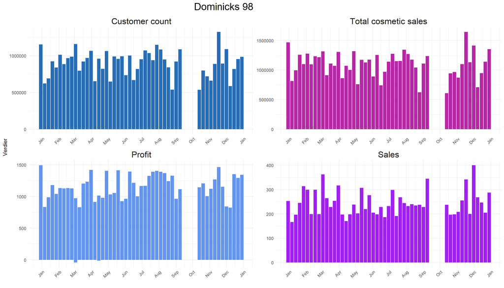

```r
# Starting the plot
dominicks_98_long %>%
  ggplot(aes(x = date, y = values, fill = names)) +
  geom_col() + # using col for bar chart
  theme_minimal()+ # theme
  labs(x = "", y = "Verdier", # changing some names
       fill = "names", labels="", title="Dominicks 98") +
  scale_fill_manual(values = c("custcoun" = "#276DB6", # Changing colors manually
                               "haba" = "#B627A5",
                               "profit" = "cornflowerblue",
                               "sales" = "purple"))+
  # facet for 4 different figures in same plot
  facet_wrap(~ names, scales="free", labeller = labeller(names = c("custcoun" = "Customer count",
                                                                  "haba" = "Total cosmetic sales",
                                                                  "profit" = "Profit",
                                                                  "sales" = "Sales")))+
  # Setting some adjustments in the theme for positions of title and legend
  theme(legend.position = "none", axis.text.x = element_text(angle = 45, hjust = 1),
        plot.title = element_text(hjust = 0.4, size=20), strip.text = (element_text(size = 17)))+
  # Fixing the x-axis to show months
  scale_x_date(date_breaks = "1 month", date_labels = "%b")
```

```r
# We ended up not using this figure, if you wondered why there is a code-fold here
#| column: page
brand_colors <- c("Bold Hold" = "#1f77b4",
                  "Head and Shoulders" = "#ff7f0e",
                  "Ivory" = "#2ca02c",
                  "Spirit" = "#d62728",
                  "Vo5" = "#9467bd")



old_fig <- dominicks_98 %>%
  mutate(haba = haba / 1000,
         brand = case_when(
           brand == "bold_hold" ~ "Bold Hold",
           brand == "head_and_shoulders" ~ "Head and Shoulders",
           brand == "ivory" ~ "Ivory",
           brand == "spirit" ~ "Spirit",
           brand == "vo5" ~ "Vo5"
         )) %>%
  plot_ly() %>%
  add_trace(x = ~date, y = ~haba, type = 'bar', split = ~brand, color = ~brand, colors = brand_colors,
            text = ~brand, hovertemplate = "Brand: %{text}<br>Value: %{y}<extra></extra>") %>%
  layout(title = list(text = "Dominicks 98", xref = "paper", x = 0.4),
         xaxis = list(title = "", tickformat = "%b", dtick = "M1"),
         yaxis = list(title = "Verdier i dollar(1000)"),
         legend = list(orientation = "h", x = 0.5, y = -0.1, xanchor = "center"),
         barmode = 'stack',
         annotations = list(
           list(text = "Weekly sales for shampoo", xref = "paper", yref = "paper", x = 0.4, y = 0.99, showarrow = F, font = list(size = 12))
         )) %>%
  config(displayModeBar = FALSE)

#old_fig
```

```r
# Defining colors for each brand
dominicks_98_colors <- dominicks_98 %>%
  mutate(brand = case_when(
    brand == "bold_hold" ~ "Bold Hold",
    brand == "head_and_shoulders" ~ "Head and Shoulders",
    brand == "ivory" ~ "Ivory",
    brand == "spirit" ~ "Spirit",
    brand == "vo5" ~ "Vo5")
  ) %>%
  mutate(color = brand_colors[brand]) %>%
  mutate(week = as.integer(format(date, "%W")))

dominicks_98_plot <- dominicks_98_colors %>%
  split(.$brand) %>%
  map(
    ~ ggplot(data = .x, aes(x = week, y = haba / 1000, fill = brand,
                     text = paste0("Week: ", week, "<br>",
                     "Brand: ", brand, "<br>",
                     "Health and beauty sales in thousands: <br>$", haba / 1000))) +
      geom_col() +
      scale_fill_manual(values = unique(.x$color)) +
      theme_minimal() +
      labs(x = "Week", y = "Dollar sales for each brand (1000)") +
      scale_x_continuous(expand = c(0, 0), breaks = seq(1, 52, by = 1), labels = seq(1, 52, by = 1)) +
      theme(axis.text.x = element_text(angle = 45, hjust = 1, size = 7), plot.title = element_text(hjust = 0.4)) +
      ggtitle(paste(unique(.x$brand)))
  )


# Convert ggplot objects to Plotly plots
dominicks_98_plotly <- dominicks_98_plot %>%
  map(~ggplotly(.x, tooltip = "text"))


# Print each modified plot
dominicks_98_plotly[[1]]
dominicks_98_plotly[[2]]
dominicks_98_plotly[[3]]
dominicks_98_plotly[[4]]
dominicks_98_plotly[[5]]
```

[interactive chart not shown]

```r
brand_list <- c("Bold Hold", "Head and Shoulders", "Ivory", "Spirit", "Vo5")
brand_map <- c("bold_hold" = "Bold Hold",
               "head_and_shoulders" = "Head and Shoulders",
               "ivory" = "Ivory",
               "spirit" = "Spirit",
               "vo5" = "Vo5")

for (brand in brand_list) {
  original_brand_name <- names(brand_map)[brand_map == brand] # get the original brand name

  brand_data <- dominicks_98 %>%
    mutate(haba = haba / 1000,
           brand = case_when(
             brand == original_brand_name ~ brand
           )) %>%
    filter(brand == brand)

  plot_ly(brand_data) %>%
    add_trace(x = ~date, y = ~haba, type = 'bar', color = ~brand, colors = brand_colors[brand],
              text = ~brand, hovertemplate = paste("Brand: ", brand, "<br>Value: %{y}<extra></extra>")) %>%
    layout(title = list(text = paste("Dominicks 98 - ", brand), xref = "paper", x = 0.4),
           xaxis = list(title = "", tickformat = "%b", dtick = "M1"),
           yaxis = list(title = "Verdier i dollar(1000)"),
           legend = list(orientation = "h", x = 0.5, y = -0.1, xanchor = "center"),
           annotations = list(
             list(text = paste("Weekly sales for", brand), xref = "paper", yref = "paper", x = 0.4, y = 0.99, showarrow = F, font = list(size = 12))
           )) %>%
    config(displayModeBar = FALSE)
}
```

In figure 2, we look at which brand sells best among the shampoos we have selected with a lot of movement. You can see that Vo5 clearly has the largest sales volume measured in dollars, and that Head and Shoulders is not as big as they are today.

```r
# List of variables of interest
variables2 <- list(c('% of population that is white',
                     '% of population that is neither black & hispanics or white',
                     '% Blacks & Hispanics'),
                  c("% of people that arent college graduates", "% College Graduates"),
                  c("% of population with income under $15,000", "% of population with income over $15,000"),
                  c("% of households without mortages", "% of households with mortgages"))

# List to store the resulting datasets
datasets <- list()

# Loop through the variables and create the corresponding datasets
for (i in seq_along(variables2)) {
  datasets[[i]] <- demo_stata %>%
    filter(store == "98") %>%
    unique() %>%
    filter(variable_name %in% variables2[[i]])
}
```

In figure 3, the group management can see which customer group shops the most at Dominicks 98, those who contribute the most to sales in this particular store are 81% white, 1.2% other, and 17.8% black or Latin American. Further in figures 4, 5 and 6, we look at whether the customers are students, above the poverty line, and whether the customers have mortgages.

```r
variable_names <- list(c('% of population that is white',
                         '% of population that is neither black & hispanics or white',
                         '% Blacks & Hispanics'),
                       c("% of people that arent college graduates", "% College Graduates"),
                       c("% of population with income under $15,000", "% of population with income over $15,000"),
                       c("% of households without mortages", "% of households with mortgages"))

create_pie_chart <- function(dataset, variable_names) {
  pie_data <- dataset %>%
    filter(variable_name %in% variable_names) %>%
    mutate(display_value = round(dflong_value * 100, 2),
           custom_text = paste0(variable_name, ": ", display_value, "%"))

  colors <- c('blueviolet', '#B627A5', 'cornflowerblue')

  pie_chart <- plot_ly(pie_data, labels = ~variable_name, values = ~display_value, type = 'pie', textinfo = 'percent',
                       marker = list(colors = colors), text = ~custom_text, hovertemplate = "%{label}: <br>%{value}%<extra></extra>") %>%
    layout(title = "",
           legend = list(orientation = "h", x = 0.5, y = -0.3, xanchor = "center")) %>%
    config(displayModeBar = FALSE)

  return(pie_chart)
}



plots <- pmap(list(datasets, variable_names), create_pie_chart)
```

```r
 plots[[1]]
 plots[[2]]
 plots[[3]]
 plots[[4]]
```

[interactive chart not shown]

## Task 3

```r
#CURSED

week_225_start <- as.Date("1994-01-01")#Overwriting start date


df_monthly <- df %>%
  ungroup() %>%
  mutate(date = week_225_start + (week - 225) * 7) %>%
  mutate(month = month(date)) %>%
  select(-date, -week) %>%
  group_by(month, brand) %>%
  summarise_all(sum)
```

First, we will present monthly values for all Dominick’s stores from the entire chain. We can see these in the figure below.

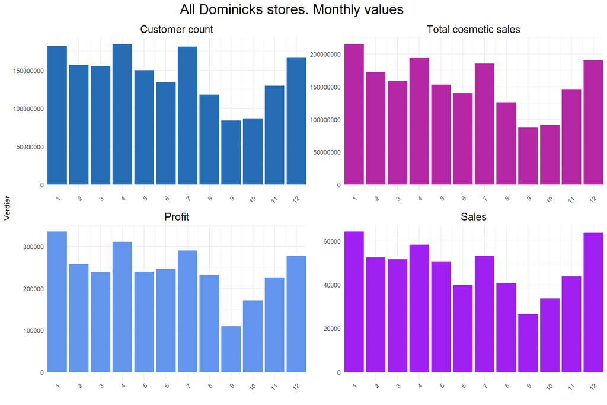

```r
df_monthly %>%
  pivot_longer(cols = c(sales, haba,custcoun, profit),
               names_to = "names", values_to = "values") %>%
  ggplot(aes(x = month, y = values, fill = names)) +
  geom_col() + # using col for bar chart
  theme_minimal()+ # theme
  labs(x = "", y = "Verdier", # changing some names
       fill = "names", labels="", title="All Dominicks stores. Monthly values") +
  scale_fill_manual(values = c("custcoun" = "#276DB6", # Changing colors manually
                               "haba" = "#B627A5",
                               "profit" = "cornflowerblue",
                               "sales" = "purple"))+
  # facet for 4 different figures in same plot
  facet_wrap(~ names, scales="free", labeller = labeller(names = c("custcoun" = "Customer count",
                                                                  "haba" = "Total cosmetic sales",
                                                                  "profit" = "Profit",
                                                                  "sales" = "Sales")))+
  # Setting some adjustments in the theme for positions of title and legend
  theme(legend.position = "none", axis.text.x = element_text(angle = 45, hjust = 1),
        plot.title = element_text(hjust = 0.4, size=20),strip.text = element_text(size = 15))+
  scale_x_continuous(expand=c(0,0), n.breaks = 12)
```

Next, we look at which brands are doing well. As in the previous task, we can see that Vo5 is selling the best across all of Chicago. NB: The y-axis has different scales on the different plots.

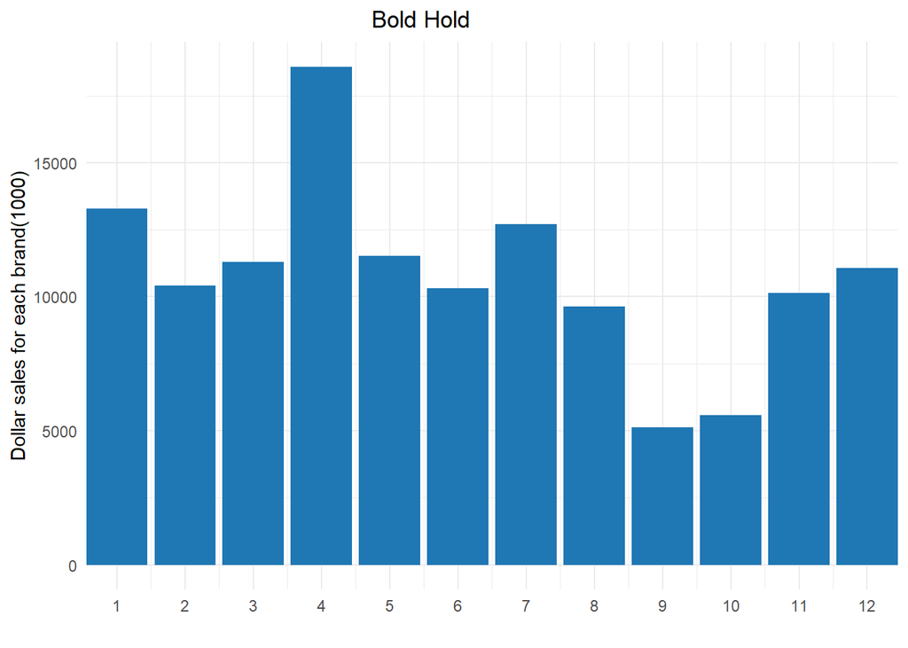

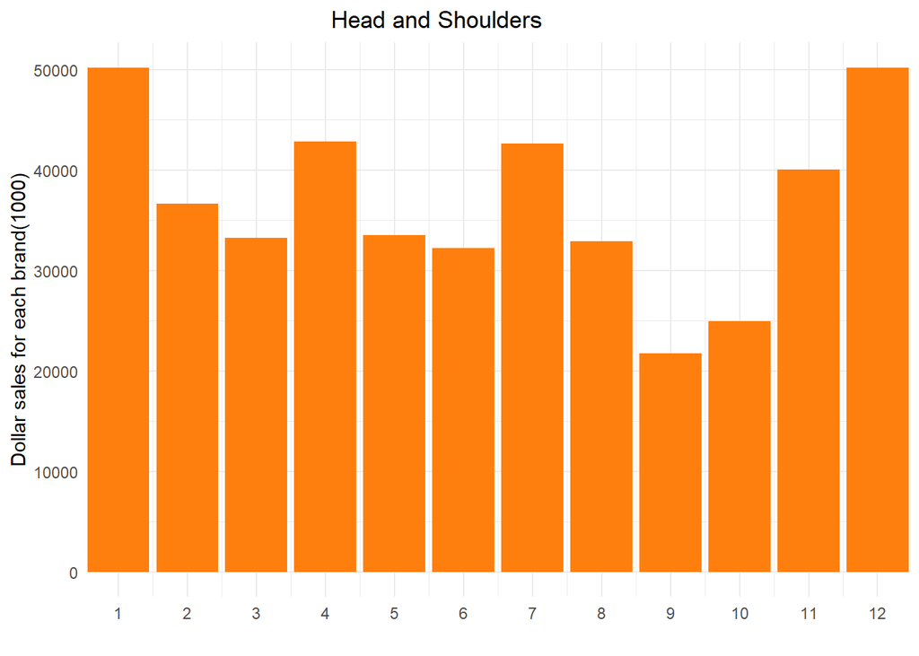

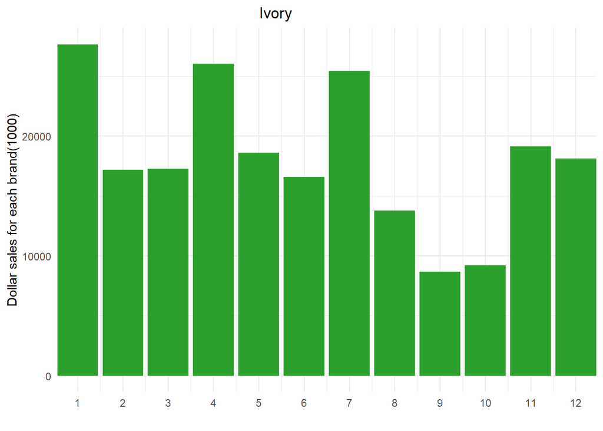

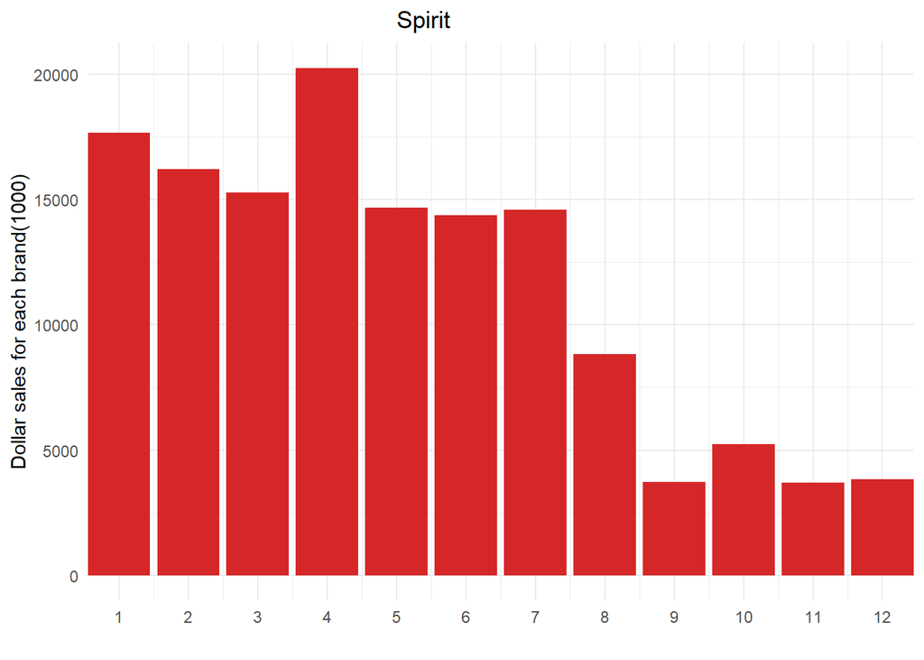

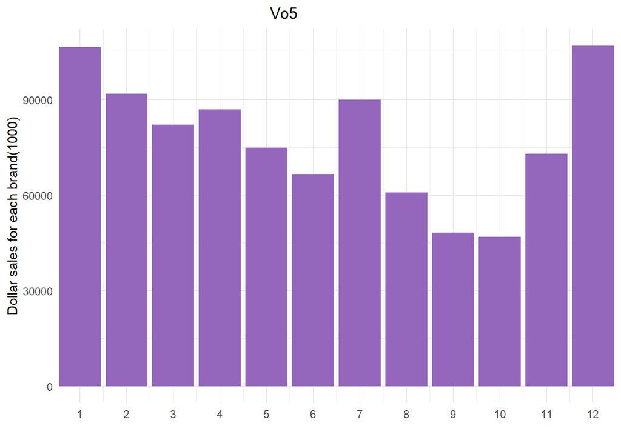

```r
# Define colors for each brand
brand_colors <- c("Bold Hold" = "#1f77b4",
                  "Head and Shoulders" = "#ff7f0e",
                  "Ivory" = "#2ca02c",
                  "Spirit" = "#d62728",
                  "Vo5" = "#9467bd")


df_monthly_with_colors <- df_monthly %>%
  mutate(brand = case_when(
           brand == "bold_hold" ~ "Bold Hold",
           brand == "head_and_shoulders" ~ "Head and Shoulders",
           brand == "ivory" ~ "Ivory",
           brand == "spirit" ~ "Spirit",
           brand == "vo5" ~ "Vo5")) %>%
  # Add a color column based on brand
  mutate(color = brand_colors[brand])

plots_monthly <-df_monthly_with_colors %>%
    split(.$brand) %>%
    map(~ ggplot(data = .x, aes(x = month, y = haba/1000, fill = color)) +
          geom_col() +
          scale_fill_identity() +
          theme_minimal() +
          scale_x_continuous(expand = c(0,0), n.breaks = 12) +
          labs(x="",y="Dollar sales for each brand(1000)")+
          theme(plot.title = element_text(hjust = 0.4))+
          ggtitle(paste(unique(.x$brand))))

# Print each plot
invisible(map(plots_monthly, print))
```

## Task 4

```r
loc_data <- demo_stata[!duplicated(demo_stata[,c("store")]),]

loc_data <- loc_data %>%
  select(-dflong_value, -variable_name)

loc_data %>%
  mutate(lat = lat/10000, long = long/10000*-1) %>%
  leaflet() %>%
  addTiles(options = tileOptions(minZoom=10, maxZoom=13)) %>%
  addCircleMarkers(clusterOptions = markerClusterOptions(maxClusterRadius = 20),
                   lat = ~lat, lng = ~long, #locations for markers
                   radius = 12, #circle size
                   color = "red", #color of circle
                   fillOpacity = 0.5,
                   stroke = FALSE, #no outline
                   label = ~as.character(store), #store labels
                   labelOptions = labelOptions(noHide = TRUE, direction = "center", textOnly = TRUE, fontSize = 16, fontWeight = "bold"),
                   popup = paste0("<strong>Store:</strong>", loc_data$store,
                                  "<br><strong>Name:</strong>", loc_data$name,
                                  "<br><strong>City:</strong>", loc_data$city,
                                  "<br><strong>Zip:</strong>", loc_data$zip,
                                  "<br><strong>Profit from shampoo sales:</strong> $", loc_data$profit,
                                  "<br><strong>Total shampoo sales:</strong> $", loc_data$sales,
                                  "<br><strong>Customer count</strong>(thousands): ", round(loc_data$custcoun/1000),
                                  "<br><strong>Health and beauty sales</strong>(thousands): ", round(loc_data$haba/1000)))
```

[interactive chart not shown]

The data we have can be used to find new and suitable retail outlets. What we can do, for example, is to look at the best retail outlets we already have over time in aggregate, then take a regression analysis of, for example, the 5 or 10 best places and see if the customer flow has changed positively over time. If we then manage to find a location that is popular and has an increasing customer group, we can see if there are any locations nearby where we can set up a new store to cater to the increasing customer flow.

```r
#making an empty list
model_list <- list()

#looping to add to the lsit
for (store_id in unique(df$store)) {

  #Subset the data for the current store
  store_data <- subset(df, store == store_id)

  #fitting the model
  model <- lm(custcoun ~ date, data = store_data)

  #adding the model and coefficients into the list
  model_list[[as.character(store_id)]] <- list(model = model, coef = coef(model))

}

#Getting the coefficients and r-squared values for all stores
coef_df <- data.frame(do.call(rbind, lapply(model_list, function(x) x$coef)))
```

Shows top 10 stores with increasing customer trend.

```r
table <- coef_df %>%
  arrange(-date) %>%
  rownames_to_column(var = "store") %>%
  mutate(store = as.numeric(store))

table_names <- table %>%
  rename("Intercept" = X.Intercept., Coefficient = date) %>%
  slice_head(n = 10)

table_names
```

| store | Intercept | Coefficient |
| --- | --- | --- |
| 8 | -1595356.1 | 192.01665 |
| 80 | -1569729.5 | 187.34824 |
| 78 | -970100.1 | 116.64968 |
| 107 | -675057.0 | 90.44691 |
| 86 | -481841.6 | 65.11091 |
| 129 | -399563.1 | 57.46547 |
| 84 | -379781.5 | 54.01417 |
| 139 | -291179.8 | 48.66049 |
| 77 | -302744.0 | 44.45087 |
| 137 | -244790.8 | 40.76657 |

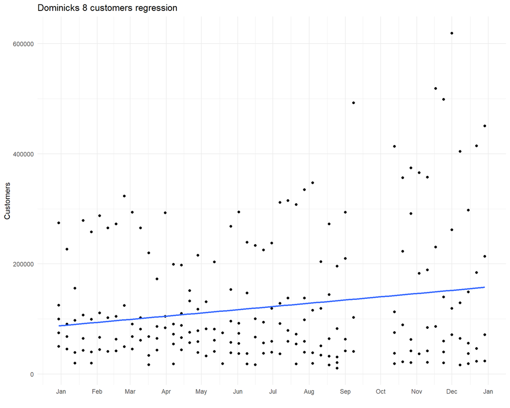

```r
# Plotting the most promising store
df %>%
  filter(store == 8) %>%
  ggplot(aes(x=date,y=custcoun)) +
  geom_point()+
  geom_smooth(method=lm, se=FALSE)+
  labs(x="", y="Customers", title="Dominicks 8 customers regression")+
  theme_minimal()+
  scale_x_date(date_breaks = "1 month", date_labels = "%b")
```

The results from the regression analysis show that store 8 has the most increasing customer flow. If we look at the map above, this location has good coverage of Dominicks stores. What we should be able to see is what this store does better than the others we have in the area already, and if a new store is to be set up, it should be further east. Otherwise, when we look at the map above, the location that could have more stores is West Chicago, for example with Winfield.

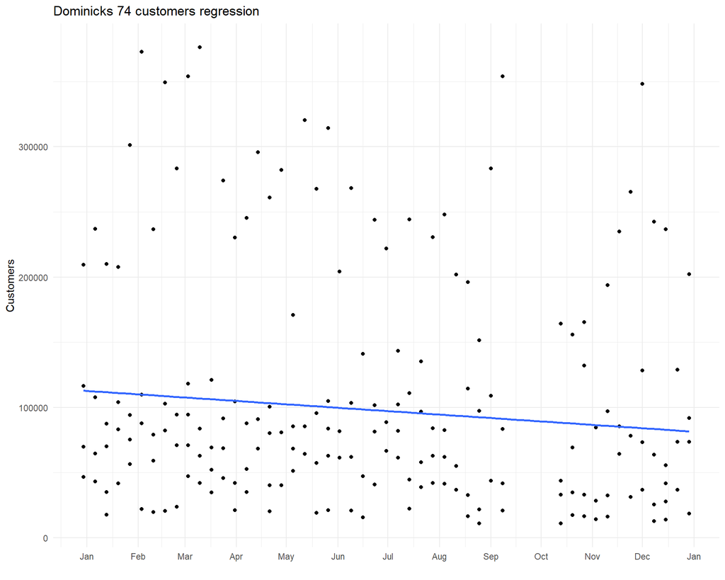

```r
df %>%
  filter(store == 74) %>%
  ggplot(aes(x=date,y=custcoun)) +
  geom_point()+
  geom_smooth(method=lm, se=FALSE)+
  labs(x="", y="Customers", title="Dominicks 74 customers regression")+
  theme_minimal()+
  scale_x_date(date_breaks = "1 month", date_labels = "%b")
```

Dominicks 74 is the store with the most declining customers.

```r
table <- coef_df %>%
  arrange(-date) %>%
  rownames_to_column(var = "store") %>%
  mutate(store = as.numeric(store))


palette <- colorNumeric(palette = c("red", "green"), domain = loc_data$sales)



loc_data %>%
  mutate(lat = lat/10000, long = long/10000*-1) %>%
  leaflet() %>%
  addTiles(options = tileOptions(minZoom=9, maxZoom=13)) %>%
  addCircleMarkers(clusterOptions = markerClusterOptions(maxClusterRadius = 20),
                   lat = ~lat, lng = ~long, #locations for markers
                   radius = 12, #circle size
                   color = ~palette(sales), #color of circle based on sales
                   fillOpacity = 0.5,
                   stroke = FALSE, #no outline
                   label = ~as.character(store), #store labels
                   labelOptions = labelOptions(noHide = TRUE, direction = "center", textOnly = TRUE, fontSize = 16, fontWeight = "bold"),
                   popup = paste0("<strong>Store:</strong>", loc_data$store,
                                  "<br><strong>Name:</strong>", loc_data$name,
                                  "<br><strong>City:</strong>", loc_data$city,
                                  "<br><strong>Zip:</strong>", loc_data$zip,
                                  "<br><strong>Profit from shampoo sales:</strong> $", loc_data$profit,
                                  "<br><strong>Total shampoo sales:</strong> $", loc_data$sales,
                                  "<br><strong>Customer count</strong>(thousands): ", round(loc_data$custcoun/1000),
                                  "<br><strong>Health and beauty sales</strong>(thousands): ", round(loc_data$haba/1000))) %>%
  addLegend(pal = palette, values = ~sales, title = "Shampoo total<br> dollar sales ($)")
```

[interactive chart not shown]

On this interactive map, we can finally see that it is primarily the central Chicago stores that are doing the best and those on the outskirts that are doing the worst. Our conclusion is that it is in those areas in the middle of Chicago with the least coverage where it will be most profitable to set up a new store or multiple new stores. And by running a code that we had help from ChatGPT to see there might be some form of correlation. However for the correlation numbers it is important to note that statsistical significance is important when interpreting correlations, the correlation may be not zero but if its not statistically significant then it may not be meaningful to look at. We have not used any form of statistical test as we lack the knowledge to do this in a meaningful way but we felt it may be relevant to look at.

```r
correlations <- demo_stata %>%
  pivot_wider(names_from = variable_name, values_from = dflong_value)

#This code is with the use of ChatGPT
# List of demographic columns
demographic_cols <- colnames(correlations)[5:6]

# Initialize an empty vector to store correlation results
correlation_results <- c()
#This code is with the use of ChatGPT
# Calculate correlation for each demographic variable
for (col in demographic_cols) {
  correlation <- cor(correlations$sales, correlations[[col]], use = "pairwise.complete.obs")
  correlation_results <- c(correlation_results, correlation)
}

# Combine demographic column names and correlation results into a dataframe
correlation_df <- data.frame(Demographic = demographic_cols, Correlation = correlation_results)
#This code is with the use of ChatGPT
# Print the correlation dataframe
correlation_df
```

| Demographic | Correlation |
| --- | --- |
| lat | 0.1445141 |
| long | -0.1655860 |

This shows us that there is maybe a good idea to have stores with a higher value of latitude which is to the north, and a lower longtitude which is to the east so having your store in the north east chigago area might be something to look into.

```r
correlations <- demo_stata %>%
  pivot_wider(names_from = variable_name, values_from = dflong_value)


#This code is with the use of ChatGPT
# List of demographic columns
demographic_cols <- colnames(correlations)[14:ncol(correlations)]

# List of variables for which you want to calculate correlations
variables <- c("sales", "profit", "custcount", "haba")

# Initialize an empty dataframe to store correlation results
correlation_df <- data.frame()
#This code is with the use of ChatGPT
# Calculate correlation for each demographic variable
for (var in variables) {
  correlation_results <- c()
  for (col in demographic_cols) {
    # Ensure both columns are numeric before calculating correlation
    if (is.numeric(correlations[[var]]) & is.numeric(correlations[[col]])) {
      correlation <- cor(correlations[[var]], correlations[[col]], use = "pairwise.complete.obs")
      correlation_results <- c(correlation_results, correlation)
    } else {
      correlation_results <- c(correlation_results, NA)
    }
  }
  temp_df <- data.frame(Demographic = demographic_cols, Correlation = correlation_results, Variable = var)
  correlation_df <- rbind(correlation_df, temp_df)
}

# Subset the dataframe to keep only rows with correlation greater than 0.1 or less than -0.1. #This code is with the use of ChatGPT
correlation_df <- subset(correlation_df, abs(Correlation) > 0.1)
#This code is with the use of ChatGPT

#rownames(correlation_df) <- NULL
# Print the correlation dataframe
correlation_df
```

|  | Demographic | Correlation | Variable |
| --- | --- | --- | --- |
| 5 | % Working Women with full-time jobs | -0.1284505 | sales |
| 8 | % of Retired | 0.1091721 | sales |
| 10 | % of Unemployed | 0.1189193 | sales |
| 15 | % of households with mortgages | -0.2543562 | sales |
| 16 | % of households without mortages | 0.2543562 | sales |
| 21 | % of population that is neither black & hispanics or white | 0.1850833 | sales |
| 26 | % of women that arent working | 0.1284505 | sales |
| 27 | % of working women with children | -0.2062318 | sales |
| 28 | % of working women with children 6 - 17 | -0.2004089 | sales |
| 31 | % Blacks & Hispanics | -0.2206697 | profit |
| 32 | % College Graduates | -0.1124497 | profit |
| 45 | % of households with mortgages | -0.1341649 | profit |
| 46 | % of households without mortages | 0.1341649 | profit |
| 47 | % of non-working women with children | 0.1022449 | profit |
| 49 | % of people that arent college graduates | 0.1124497 | profit |
| 52 | % of population that is non-white | -0.2049068 | profit |
| 53 | % of population that is white | 0.2049068 | profit |
| 93 | % Population over age 60 | -0.1037599 | haba |
| 94 | % Population under age 9 | 0.1508498 | haba |
| 100 | % of Unemployed | 0.2141608 | haba |
| 102 | % of households with 2 persons | -0.1555487 | haba |

The variable “haba” means health and beauty sales.

What we can see here is that there might be some signs of there being some correlation with demographic data but we can not be sure. Further analysis is needed.

## References

The data used for this assignment is gathered at the following links

https://www.chicagobooth.edu/research/kilts/datasets/dominicks

https://www.chicagobooth.edu/-/media/enterprise/centers/kilts/datasets/dominicks-dataset/dominicks-manual-and-codebook_kiltscenter

We have also used the resources from the courseplan in SOK-1005 and used the lectures given by Dejene Gizaw Kidane to help us create the code to wrangle the data so there may be similarities at places in Task 1. However any and all errors are ours and ours alone.

The lectures are found here https://github.com/uit-sok-1005-v23/uit-sok-1005-v23.github.io

Some of the code used to create some of the figures and datawrangling has been taken from our delivered assignments. The candidat numbers are added in the top of the document and we have delivered the assignments in Canvas with links to our Github pages. However for the purpose of anonymity of the authors of this task, our github pages contain our names so this should only first be checked after grading is final.

## Appendix for AI usage

### Task 1

In the beginning of Task 1 there has been use for ChatGPT to help define the start of “week 1” as we were unsure of how to convert the weekly data to date but it gave us the idea which we used to create the code. Codeline 136 and 146

We used ChatGPT to enter in the variable names after posting the variable names from the PDF. Codelines 157-67

In the code line 251 we had help from ChatGPT to write the REGEX code to help us pick out the brands as the brands had weird names with changing use of letters and such.

Finally we have used ChatGPT to help us translate the documentation we had made for Task1 to english by promting it with “translate to english” and adding our text. This was done to help grade the task.

### Task 2

Helped make a trycatch code so if file isnt found, it is gotten from github where it is hosted

ChatGPT has been used to help create a better structure in the text we have made. This has been done by promting the model with our text and asking it to improve it. With some translations

### Task 3

Minimal usage

Again used to help create better structure in the text and at times translate our norwegian comments.

### Task 4

The use of ChatGPT is shown on this [link](https://chat.openai.com/share/467d2e00-f0ba-47e8-85d7-04bba3c88f20) and we translated one section to english in task 3.

The link shows us promting ChatGPT saying we have a dataframe in R and explaining a bit of the dataframe. The AI then gives us some code and i then specify we want specific columns to be checked. It then gives the code that is used at the end of Task 4 and it has been changed minimally.

Lastly it shows that i asked it to translate a section of Task 3 to to english which was done to help grade this task.